# Data Science for Socioeconomists

Excercise 3 and 4 - Data and Functions

Lisa Wegner & Junbo Huang

# Agenda for today:

1. Recap on functions
2. Recap on loading data
3. Tasks for today

# 1. Recap on functions

- Functions are objects that include statements that are run together every time the function is called
- Functions make codes more elegant, help avoiding mistakes and make code easier to read

They can be built-in or self-written

## using built in functions

*How is the function structured? What arguments do we need to hand over?*

- we can use the “help” function in R-Studio by directly searching for the function that we want to use - or type `?as.data.frame` into the console/a code block to also be guided to the documentation.
- when typing `as.data.frame(` we also get help from the auto-fill function of R-Studio and get a hint of what values we need to give to the function)

## Writing your own functions

```r
# in the lecture you learned
x <- 10
y <- 5
result <- x+y
print (result)
```

```
[1] 15
```

```r
# you could also write this as a function:
addition_function <- function(x,y){
  z <- x+y
  return (z)
  }
result <- addition_function(10,5)
print (result)
```

```
[1] 15
```

## Taking a closer look

[figure not shown]

# 2. Recap on loading data

- data can be stored in various formats
- today we want to focus on csv (excel) files and data packages

## reading csv files with readr package

When opening our dataset in excel we see: a`ge,"spending_habits","income","gender"`values separated by `,`

therefore `read_csv` should work

1. download dataset to own computer
2. upload to JuypterHub

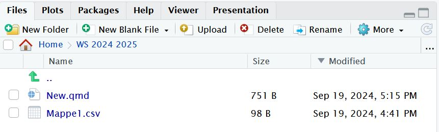

3. the csv should be in the same folder as the one that you are currently working in
4. readr-package: Install (if nessecary) and load to library

   `library(readr)`
5. load dataset

   `test_dataset <- read_csv("Dataset.csv")`

## Loading data - from packages

In our course we will use a data package. It contains data sets and descriptions of the different variables. The package consists of several data sets:

| [airbnbbig](http://127.0.0.1:11415/help/library/sozoekds/html/airbnbbig.html) | This data set comprises Airbnb listings in London, UK from 2009 to 5th November 2019. Please note: this is the bigger version of the data set. |
| --- | --- |
| [airbnbsmall](http://127.0.0.1:11415/help/library/sozoekds/html/airbnbsmall.html) | This data set comprises Airbnb listings in London, UK from 2009 to 5th November 2019. Please note: this is the smaller version of the data set. |
| [calhouse](http://127.0.0.1:11415/help/library/sozoekds/html/calhouse.html) | The data pertains to the houses found in a given California district and some summary stats about them based on the 1990 census data. |
| [examscores](http://127.0.0.1:11415/help/library/sozoekds/html/examscores.html) | This data set includes scores from three test scores of students at a (fictional) public school and a variety of personal and socio-economic factors that may have interaction effects upon them. |
| [testdata](http://127.0.0.1:11415/help/library/sozoekds/html/testdata.html) | Random generated numbers and values for explanatory purpose. |

#### installation

This package is not on CRAN - we hosted it on another server. R needs additional info to find it:

```r
# install.packages("remotes")
library(remotes)
remotes::install_gitlab("BAQ6370/sozoekds", host="gitlab.rrz.uni-hamburg.de")
library(sozoekds)
```

```r
#install.packages("devtools")
library(devtools)
devtools::install_git("https://gitlab.rrz.uni-hamburg.de/baq6370/sozoekds.git")
library(sozoekds)
```

we can use the data from the loaded package directly by calling it:

`airbnbbig`

# Tasks for Today

## using functions

Take this vector and answer the following questions by using programming/code:

```r
vector <- c(19,3,8,7,24,43,89,76,17,32,8,9,350,56)
```

1. What is the lowest number of the vector?

2. What is the mean value? What is the median value? How far are they apart from each other?

3. How big is the range of the vector?

## Calculator Function

We want a function that…

- calculates the sum of the square roots of two numbers,
- rounds it to two digits
- and then does a check: when the result is bigger than a third number return: bigger then z, otherwise return: smaller then z
- [hint: check out if-else-conditions]
- check by using x=10, y=20 and z=40

## loading data into R

1. first load the data-set Exam_Score (can be found at OpenOlat) into R using package-functions of readr (the data-set is in csv-format).

2. load the data-set Cal_Housing from our package “sozoekds” (load & install this package first, then load the data-set)

## descriptive analysis (for Exam data)

- How many variables are there?
- Type of those variables?
- Calculations: Mean, Median, Range - what do you think is helpful (and why) to get a good overview over your data
- Are there other ways to get an overview over the data?

## New variables - for the exam data:

- Transform ethnic group to factor
- calculate the total points in all tests per person
- use 300 as 100% and calculate the percentage of answers that the student got right
- define a “passing” variable using 50% as the boundary for passing